# HW8

Dhanvin Lakshmisha

2025-04-12

Dhanvin Lakshmisha

dl37833

SDS 315

GitHub link - https://github.com/DhanvinL/SDS315-HW8

## Question 1

### Part A

First, we fit the model. Then we can find the coefficients.

```
## (Intercept)         age
## 147.8129158  -0.6198159
```

147.81 - (0.62)(55) = 113.71

So, for a 55-year-old,we would expect a clearance rate of around 113.71 mL/minute. I got this value by taking the equation, clearance rate = 147.81 -0.619 * (age), and inputting 55 as the age.

### Part B

Creatinine clearance rate decreases by 0.619 mL/minute for each additional year of age. This was based on the slope or age coefficient from the linear model.

### Part C

Based, on the equation, we would expect the 40 year old to get a clearance rate of 123.01 mL/minute (147.81 - (0.62) (40)). Also, we would expect the 60 year old to get a clearance rate of 110.61 mL/minute (147.81 - (0.62) (60)). If we compare the actual - predicted clearance rate for each age, we get a difference of 11.99 (which is 135 - 123.01) for the 40-year-old and a difference of 1.39 (which is 112 - 110.61) for the 60-year-old. Thus, compared to their expected clearance rate, the 40-year-old is healthier relative to their age due to them having a higher difference.

## Question 2

We can fit a linear model on log(deaths).

### Part A

Here is a 95 percent confidence interval for the slope “days_since_first_death” or the growth rate of Italy.

```
##      2.5%     97.5%
## 0.1599309 0.2082970
```

We are 95% confident that the true growth rate lies between 0.1599309, 0.208297.

Here is a 95 percent confidence interval for the doubling time of daily COVID deaths based on Italy’s growth rate.

```
##     2.5%    97.5%
## 437.6890 336.0587
```

We are 95 percent confidence that the true doubling time of daily COVID deaths for Italy is between that range.

### Part B

For Spain, here is a 95 percent confidence interval for its growth rate.

```
##      2.5%     97.5%
## 0.2362354 0.3198827
```

We are 95% confident that the true growth rate lies between 0.2362354, 0.3198827.

Here is a 95 percent confidence interval for the doubling time of daily COVID deaths based on Spain’s growth rate.

```
##     2.5%    97.5%
## 296.3147 218.8302
```

We are 95 percent confidence that the true doubling time of daily COVID deaths for Spain is between that range.

### Part C

Here is a line graph showing reported daily deaths over time for each country.

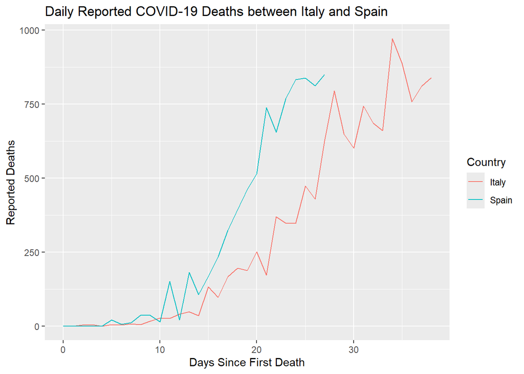

### Question 3

The elasticity of the model, derived from the log version of the power-law model, is -

```
## log_price
## -1.618578
```

Now, we can bootstrap that elasticity to generate a 95 percent confidence interval.

|  | 2.5% | 97.5% |
| --- | --- | --- |
| percentile | -1.773953 | -1.453761 |

We are 95 percent confident that the true elasticity is between -1.7739531 and -1.4537609.

To estimate the elasticity, I first fitted a log-log linear model to the power-law model. I took the logs of both “sales” and “price” and used those as parameters for creating a linear regression model, with the y-value being “log_sales” and the predictor being “log_price”. I interpreted the slope of this linear model as the elasticity due to how the log-log equation was derived. The estimate I derived was -1.6185778. I then bootstrapped the linear model, using a 1000 resamples, to construct a 95 percent confidence interval for the estimate. Finally, I got a 95 percent confidence interval of (-1.7739531, -1.4537609). We are 95 percent confident that the true elasticity of milk is in that interval.